# Измерване на икономическата дейност. Брутен вътрешен продукт и икономически растеж

## 1. Макроикономически кръгооборот

В темите досега беше показано как се нарушава и възстановява равновесието на отделни пазари и с какви проблеми се сблъскват и по какъв начин ги решават отделните участници в тях. При това, с някои малки изключения, анализът на ситуацията на отделните пазари и на поведението на участниците в тях изхождаше от презумпцията за тяхната независимост и несвързаност. Това е добра отправна точка, защото опростява анализа и го прави по-лесен. Всъщност между отделните пазари и участници съществуват множество връзки и една от силните страни на пазарния механизъм е начинът, по който ги осъществява. Икономистите се интересуват не само от конкретното производство на конкретна фирма, цената на конкретна стока и търсенето на конкретен потребител или на даден пазар, а и от производството на всички стоки и услуги в националното стопанство, общото ценово равнище, търсенето на стоки и услуги от всички потребители на всички пазари. Последните са обект на изучаване от макроикономиката. Освен тях обект на изследване за нея са икономическия растеж, стопанския цикъл, безработицата, фискалната и монетарната политика и др. Преходът от микро- към макроравнището може да бъде направен чрез *макроикономическия кръгооборот*. Това е схема, която показва в най-общ план връзките между отделните пазари и участниците в тях.

### 1.1. Опростен макроикономически кръгооборот

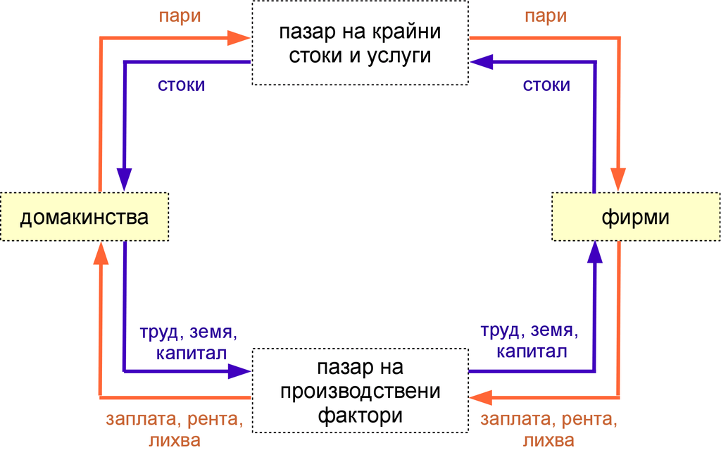

В опростения макроикономически кръгооборот отделните пазари са представени в две основни групи - първият е пазарът на крайни стоки и услуги, а вторият е пазарът на производствени фактори. Основните групи участници също са две - домакинствата и фирмите. На всеки от тези пазари участниците влизат с разменени роли. На пазара на крайни стоки и услуги домакинствата са купувачи, а фирмите са продавачи. Това генерира поток на движение на пари от домакинствата към фирмите. С получените средства от продажбата на крайни стоки и услуги фирмите са в състояние да закупят или наемат производствени фактори на пазара на производствени фактори. За целта те плащат работна заплата, рента и лихва. На този пазар домакинствата са продавачи, които предлагат труд, земя и капитал. Така се формира нов паричен поток от фирмите към домакинствата. С получените средства домакинствата са в състояние да закупят стоки и услуги от фирмите, с което кръгооборотът се затваря.

В рамките на кръгооборота това, което е разход за едни, е приход за други. Освен че позволява да се осъществи концептуално преходът между микро- и макроравнището, опростеният кръгооборот ни позволява да извлечем в един обобщен вид и два от трите метода за измерване на брутния вътрешен продукт (БВП). Представен възможно най-просто, БВП показва каква е стойността на крайните стоки и услуги, които са произведени в дадена страна за разглеждания период от време. Въпросът е как да изразим тази стойност и по какъв начин можем да я измерим. Единият начин е да измерим обема на потока на паричните разходи от домакинствата към фирмите. Това ще представи БВП по *метода на разходите за крайно потребление*. Другият начин е да проследим паричните разходи от фирмите към домакинствата под формата на заплати, ренти и лихви. Тогава БВП ще бъде изчислен по *метода на доходите*. В опростения кръгооборот единият поток е идентичен като размер на другия поток - домакинствата харчат целия си получен доход за покупката на стоки и услуги от фирмите, а самите фирми използват приходите от продажба изцяло, за да се разплатят със собствениците на труда, земята и капитала. В реалния свят нещата не са толкова прости, защото към тези потоци съществуват изземвания и добавки. Едно приближение към реалността е разширеният макроикономически кръгооборот.

### 1.2. Разширен макроикономически кръгооборот

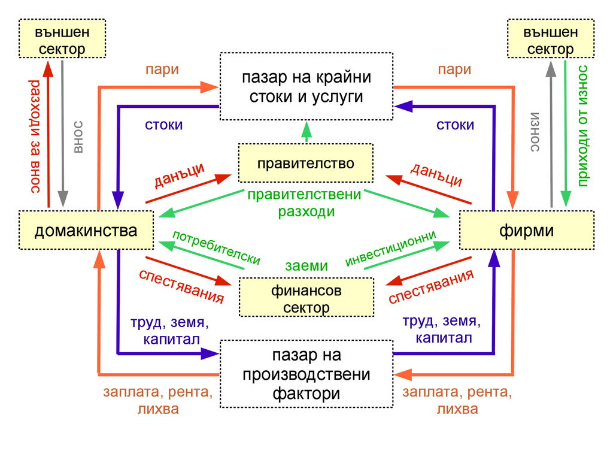

В действителност домакинствата не харчат целия получен доход за покупката на стоки и услуги, произведени на територията на страната. Те спестяват една част от него. Друга е изземвана от държавата под формата на данъци. А някои от направените разходи са за стоки и услуги, произведени в други страни. Спестяванията (S), данъците (T) и вносът (M) намаляват потока от разходи от домакинствата към фирмите и са *изземвания* от него. В същото време домакинствата могат да получат парични средства с източник, различен от дохода, който са изработили. Това могат да са трансферни плащания от правителството в рамките на социални програми или пари, които са получени като заеми от банките. Тези средства впоследствие се вливат в разходния паричен поток. Фирмите също могат да получават пари от държавата под формата на субсидии или да теглят заеми с цел инвестиции. И макар че домакинствата в страната предпочитат с част от дохода си да купят вносни стоки, една част от произведената в страната продукция се закупува от домакинства от други страни, т.е. се изнася. Колкото до правителството, освен че допринася индиректно за изземванията и добавките от кръгооборота под формата на данъци, субсидии и социални трансфери, то може да участва и пряко като потребител на пазара на крайни стоки и услуги. Така за всеки вид изземване може да се намери добавка, която му съответства. *Добавките* включват инвестициите (I), правителствените разходи (G) и износът (X).

В опростения кръгооборот националното стопанство би било винаги в равновесие, при това при пълна заетост. Тъй като няма изземвания или добавки разходите на домакинствата за крайно потребление © винаги ще са такива, че да изкупуват цялото количество произведена продукция, тъй като приходите от реализацията ѝ се разпределят като доход (Y) между различните производствени фактори. С известна условност може да кажем, че доходът и *съвкупното предлагане* (предлагането на всички стоки и услуги) са винаги тъждествени едни на други като стойности. Поради това в опростения кръгооборот няма как да се стигне до ситуация, при която има *съвкупно търсене* (търсенето на всички стоки и услуги), на което предлагането не може да отговори или да се окаже, че за една част от произведената продукция няма търсене. Представено със символи това равновесие би изглеждало по следния начин:

C=Y

Естествено, опитът показва, че това съвсем не е така и причината е съществуването на изземвания и добавки към основния макроикономически кръгооборот. Националната икономика ще бъде в равновесие само тогава, когато изземванията и добавките са равни. Или при:

S+T+M=I+G+X

Ако това не е изпълнено, равновесието в националната икономика ще бъде нарушено и ще настъпят процеси на приспособяване, които ще доведат до неговото възстановяване. Ако изземванията превишават добавките една част от продукцията няма да се изкупува и това ще бъде знак за производителите да намалят съвкупното предлагане през следващия период (което означава, че и националният доход ще намалее). Ако добавките превишават изземванията това ще даде стимул на производителите да увеличат съвкупното предлагане през следващия период (следователно и доходът ще се увеличи). Равновесието в националната икономика няма да се наблюдава във всеки един момент, а дори когато е налице, то може да се осъществява при различни равнища на заетост (когато приспособяването става чрез промени в съвкупното предлагане).

## 2. Брутен вътрешен продукт

Както вече бе посочено, БВП показва какво е количеството на произведените стоки и услуги. Трябва обаче да се направят следните уточнения:

- произведената продукция е представена в стойностно изражение по пазарни цени. Това е единственото общо кратно между разнородните по характер стоки и услуги;
- отчитат се стойностите на крайните продукти. Тъй като първичните и междинните продукти пренасят стойността си във всеки следващ продукт по производствената верига, тяхната стойност е включена в стойността на крайната стока или услуга. Самостоятелното отчитане на стойностите на първичните или междинните продукти би довело до повторното броене на една и съща стойност;
- измерването е ограничено във времето и пространството. Ако не е изрично упоменато друго, обикновено периодът обхваща една календарна година. Понякога се представят данни за БВП за полугодието или тримесечието. Територията по принцип е някаква национална държава, но в определени случаи може да бъдат представени данни за някои нейни административни или статистически единици или за наднационални формирования (като Европейския съюз).

### 2.1. Методи за измерване на БВП

Въпреки че има различни методи за измерването на БВП, те в крайна сметка измерват едно и също нещо и при прецизност на данните и отсъствие на грешки би трябвало да се получат едни и същи резултати.

#### 2.1.1. Метод на разходите за крайното потребление

Този метод се нарича още метод на крайното използване или просто разходен подход и като начин за измерване е най-близо до концепцията за БВП, представена по-горе, заради което е логично да бъде първият разгледан метод. Той представлява потока от разходи за всички крайни стоки и услуги.

С оглед на това можем да представим компонентите на този подход като различните видове разходи, които формират този поток. Едно от възможните разграничения е свързано с представянето им в разширения макроикономически кръгооборот. Тогава БВП ще изглежда по следния начин:

БВП=C+I+G+Nx

, където

C - разходи за потребление на домакинствата  
I - разходи с инвестиционна цел на фирмите  
G - правителствени разходи  
Nx - нетен експорт (X-M), който представлява разликата между стойността на износа и стойността на вноса.

Националният статистически институт (НСИ) използва “Европейската система от сметки, 2010” (ЕСС 2010), при която има допълнителна диференциация между компонентите. Според нея БВП по [метода на крайното използване](http://www.nsi.bg/bg/content/2212/) се състои от:

- индивидуално потребление, което включва:
  - крайни потребителски разходи на домакинствата
  - крайни потребителски разходи на нетърговските организации
  - крайни разходи на правителството за индивидуално потребление
- колективно потребление
- бруто капиталообразуване
  - бруто образуване на основен капитал
  - изменение на запасите
- външнотърговско салдо.

Крайните потребителски разходи на домакинствата включват всички стоки и услуги, които се закупуват от тях с цел непосредствена консумация - храна, дрехи, ток, вода, развлечения и т.н. Тук се се остойностява и потребление, за което реално не се осъществява парично заплащане. Към него спадат стоките, произведени от домакинствата за собствено потребление, а също и условно начислена рента на жилищата, заемани от техните собственици. Разходите на нетърговските организации са свързани със стоки или услуги, които те предлагат на домакинствата безплатно или по икономически незначими цени. Те се измерват със стойността на продукцията, която създават въпросните организации. Разходите на правителството за индивидуално потребление са за предоставени индивидуални услуги на домакинствата в областта на здравеопазването, образованието и други. Те се измерват със стойността на продукцията, намалена със заплатените от потребителите такси (ако има такива). Колективното потребление се измерва с крайните разходи на правителството за колективни услуги, които се ползват от обществото като цяло. Към тях спадат разходи по поддръжка на населените места, издръжка на администрацията, национална отбрана и др. Бруто образуване на основен капитал включва разходи за покупка на активи, които се използват многократно в производствения процес за продължителен период. Това включва покупката на сгради, машини, софтуер и т.н. Остойностяват се и активите, които фирмите са произвели и потребяват сами. Изменението на запасите се отнася до промяната в запасите от суровини и материали, незавършена продукция и произведена, но непродадена продукция. Външнотърговското салдо е разликата между стойността на изнесените и внесените стоки и услуги.

Важна особеност при този метод е, че се отчитат само крайните разходи за новопроизведени стоки и услуги. Препродажбата на такива, които са произведени в предишни периоди, не се отчита в БВП за текущия период със стойността на актива. В такива случаи БВП може да се промени само със стойността на някаква съпътстваща сделката услуга, създадена през текущия период (например комисионна на посредник при продажба на жилище).

#### 2.1.2. Метод на доходите

Този метод представя БВП като сума от доходите на собствениците на производствените фактори. Изхождайки от концепцията на макроикономическия кръгооборот това са възнагражденията на труда, земята и капитала. Тогава неговите компоненти ще са:

- работна заплата и доход от самонаемане
- рента
- лихва, дивиденти, печалба, амортизационни отчисления
- косвени данъци.

Трябва да добавим последното, защото косвените данъци са начислени в цените на крайните стоки и услуги, следователно фигурират в БВП по метода на разходите за крайно потребление, а трябва да се получи равенство в получения резултат, независимо от метода за измерване. Затова косвените данъци се извеждат като компонент на метода на доходите. Те са своебразен доход на държавата, заради това че осигурява условията за осъществяване на стопанска дейност като гарантира правата на собственост и изпълнението на договорните задължения.

При възприетата от НСИ методология данните се групират по малко по-различен начин. БВП по [метода на доходите](http://www.nsi.bg/bg/content/2212/) има следните компоненти:

- компенсация на наетите (разходи за труд и социални осигуровки за сметка на работодателя). Тук се включва паричната компенсация, така и компенсацията в натура
- нето други данъци върху производството и вноса (тоест данъци минус субсидиите)
- брутен опериращ излишък/брутен смесен доход
  - потребление на основен капитал
  - нетен опериращ излишък/нетен смесен доход
- корективи.

Компенсацията на наетите включва освен парична и компенсация в натура. Брутният опериращ излишък/брутният смесен доход се получава, когато от стойността на произведената продукция се извади стойността на междинните продукти заедно със стойността на другите компоненти (тоест компенсацията на наетите и нето други данъци върху производството и вноса). Следователно той има остатъчна стойност. Тя може да се разпредели за изплащането на дивиденти, лихви, предприемаческа печалба, рента, потребление на основен капитал. Когато от тази остатъчна стойност се приспадне потреблението на основен капитал (тоест амортизациите), се получава нетен опериращ излишък/нетен смесен доход. Разликата между опериращия излишък и смесения доход се състои в това къде се реализират. Опериращият излишък се отнася до фирми, които са самостоятелни юридически лица (например акционерни дружества и дружества с ограничена отговорност), а смесеният доход се реализира във фирми, които не са отделен правен субект от собственика (например едноличен търговец). Много често в такива фирми самият собственик извършва дейности, за които по принцип се получава работна заплата. Тъй като собственикът не плаща такава сам на себе си, възнаграждението за собствения му труд формира една част от смесения доход.

Докато при измерването на БВП по метода на крайното потребление се ограничаваме само до сумата от стойностите на крайните стоки и услуги, при метода на доходите се събират всички доходи, независимо дали са получени при производството на крайни или междинни продукти.

#### 2.1.3. Производствен метод

Брутният вътрешен продукт по [производствения метод](http://www.nsi.bg/bg/node/2206) се измерва с добавената стойност, създадена при производството на стоките и услугите на съответната територия. Добавената стойност се получава, като от стойността на новопроизведения продукт се извадят стойностите на всички продукти (или услуги), участващи в неговото производство. При измерването на БВП по този метод се събират всички добавени стойности, независимо дали са получени при производството на междинни или крайни стоки и услуги. Към тях се добавят и корективи (косвени данъци).

### 2.2. Недостатъци на БВП като измерител

Недостатъците на БВП като измерител могат да се наблюдават по две направления. Първо, доколко БВП наистина успява да обхване произведената продукция в една страна. И второ, доколко това може да служи като измерител на благосъстоянието на нейните жители. По отношение на първия недостатък някои от проблемите бяха частично преодоляни с въвеждането на новата методология за измерване ЕСС 2010. Тя влезе в сила в България в края на 2014 г. и [отчита](http://www.nsi.bg/bg/content/12263/) контрабандната дейност, проституцията и търговията с наркотици. Направени са и някои [други промени](http://www.nsi.bg/bg/content/11798/) в методологията. [Преизчисленият](http://www.nsi.bg/bg/content/12574/) по новата методология БВП е по-висок средно на година с 4,5% за периода 1995-2013 г. Това увеличение е повече от [средното](http://ec.europa.eu/eurostat/statistics-explained/index.php/European_system_of_national_and_regional_accounts_-_ESA_2010#What_is_the_impact_of_ESA_2010_on_GDP.3F) за страните от Европейския съюз след преминаването към новата методология. По принцип страните с голям сив сектор и домашно производство имат подценен брутен вътрешен продукт. Трябва да се има предвид, че НСИ не събира пряко данни за дейностите от сивия сектор и нелегалната търговия, а разчита на информация от полицията и други органи. Което означава, че вероятно не са особено надеждни.

Един от недостатъците на БВП е, че представя механична сума от стойности, без значение какво стои зад тях. Така БВП на дадена страна може да се увеличи значително в година на голямо природно бедствие, когато държавата и хората мобилизират огромни ресурси, за да преодолеят щетите от него. Освен че отчита разходите за справянето с отрицателни явления, БВП може да отчете само положителните ефекти от дадена дейност, но не и отрицателните. Продукцията на предприятие, което замърсява въздуха, ще доведе до увеличаване на БВП със стойността на продукцията, без това да бъде коригирано със спада в благосъстоянието на хората заради замърсения въздух. БВП не отчита промените в количеството блага, които не минават през пазара и не се остойностяват. Такова е например свободното време. Увеличението в БВП може да се осъществи за сметка на неговото свиване или заради влошени условия на труд.

Някои други недостатъци на БВП се проявяват, когато се прави сравнение между БВП в различни периоди или между различни държави. Промяната в БВП може да е резултат от промяна в ценовото равнище. Например БВП за 2011 може да е много по-голям от БВП за 2010 г.,въпреки че произведената продукция е по-малко. За преодоляването на този проблем се изчислява реален БВП по базисни (съпоставими) цени. По принцип БВП се пресмята по текущи цени, тоест цените от годината, за която правим измерването. Този брутен вътрешен продукт се нарича *номинален*. Възможно е обаче да използваме цените от някаква друга година, с която искаме да правим сравнение. Изчисленият по този начин БВП се нарича *реален*. Но дори такова сравнение е удачно само в един сравнително кратък период. В по-дълги периоди промяната на технологиите води до появата на нови стоки и услуги, които не могат да бъдат остойностени по цени от предходна година, просто защото не ги е имало. Друг проблем е, че изменеието в цените може да отразява качествени изменения в самите продукти. Един телевизор, произведен през 2015 г. и един телевизор, произведен през 1985 г. са много различни като характеристики и възможности.

При сравнението между страните БВП се представя на глава от населението, което е логично, като се има предвид, че стойността на стоките и услугите в различните държави се изработва от различен брой хора. За да е адекватно сравнието обаче трябва да се използват едни и същи мерни единици (в случая една и съща валута) и да се отчете фактът, че съществуват различия между ценовите равнища в различните страни. Затова най-удачно е да се използва критерият БВП на глава от населението според паритета на покупателната способност (ППС). ППС показва колко единици от съответната парична единица са необходими за закупуването на определено количество стоки и услуги в съответната страна. Макар че този показател дава по-добра база за сравнение между различни страни, пак могат да се проявят определени слабости. Например това, че БВП се представя като усреднени стойности на глава от населението може да прикрива големи различия в разпределението на доходите и богатството. Така две страни с на пръв поглед едни и същи стойности на БВП могат да се различават много по отношение на благосъстоянието и стандарта на живот, на който се радват повечето хора.

Въпреки недостатъците си като измерител, като цяло БВП дава една сравнително добра представа за качеството на живот. Това може да бъде установено лесно като се направи съпоставка с данните за БВП на глава от населението на различните страни, публикувани от организации като Международния валутен фонд и Световната банка.

### 2.3. Други измерители

Друг измерител за състоянието на националната икономика, за който могат да се намерят данни, е [брутният национален доход](http://www.nsi.bg/bg/content/7831/). БНД показва колко е доходът, получен от жителите на една страна. Докато БВП е ограничен териториално, БНД е ограничен по националност. В БНД на България се включват доходите на всички българи или български фирми, независимо в коя страна са получени. В същото време някои стоки и услуги, които са произведени на територията на България, остават извън българския БНД, ако са произведени от чужденци.

## 3. Икономически растеж

### 3.1. Определение и измерване

Икономическият растеж представлява изменението в брутния вътрешен продукт през два различни периода от време. Той се измерва с неговия темп. Темпът на икономически растеж е равен на относителния прираст на брутния вътрешен продукт. Тоест

\[g = \frac{GDP_{t} - GDP_{t-1}}{GDP_{t-1}} \times 100\%\]

, където

g - темп на икономически растеж  
\(GDP_{t}\) - БВП през текущия период  
\(GDP_{t-1}\) - БВП през предходния период.

Поддържането на високи темпове на растеж е изключително важно за икономическото развитие на една страна. Дори малки разлики в растежа могат да доведат до големи разлики в БВП след известно време. Това е така, защото тези различия се натрупват. Какъв ще бъде БВП след време при зададени темпове на растеж се изчислява по следната формула:

\[fv = pv(1+g)^t\]

, където

fv - бъдеща стойност на БВП  
pv - текуща стойност на БВП  
g - средногодишен темп на растеж, предсатвен като десетична дроб  
t - брой години.

Тоест икономиката ще е с БВП, който е нарастнал повече от 2,5 пъти.

### 3.2. Видове икономически растеж

- номинален и реален. *Номиналният* БВП не отчита измененията в ценовото равнище, докато *реалният* БВП е пресметнат, след като е изчистено влиянието на инфлацията.
- потенциален и реален. *Потенциалният* е максималният темп на растеж, който може да се постигне при зададените условия, *реалният* е този, който е постигнат.
- балансиран и небалансиран. При *балансирания* растеж нарастването на икономиката се осъществява при запазването на отрасловите пропорции, докато при *небалансирания* някои отрасли растат по-бързо от другите
- екстензивен и интензивен. *Екстензивният* растеж е резултат от включването на повече ресурси в производството. *Интензивният* растеж се постига без да се увеличават използваните ресурси, а като се подобрява тяхното качество или организацията на производството
- кратксрочен и дългосрочен. *Краткосрочният* се осъществява при съществуващите технологии и ресурси, докато *дългосрочният* се реализира при тяхното изменение.

### 3.3. Теории за икономическия растеж

*Неокласическата теория* за икономически растеж се появява в края на 1950-те и се свързва с името на Робърт Солоу. Солоу смята, че производството в една национална икономика (и съответно растежа) зависи от капитала, труда и използваните технологии или Q=f(K,L,A). В този модел технологичните промени са екзогенни, т.е. те не се обясняват в рамките на модела, а са предизвикани от някакви външни за него фактори. При неизменна работна сила и технологии, растежът се осъществява от увеличаването на капитала. Капиталът обаче се сблъсква с намаляваща пределна възвръщаемост. Колкото повече се увеличава той, при равни други условия, толкова повече се забавя растежа, докато в един момент спира. В дългосрочен период растежът е възможен само при увеличение и на работната сила или при изменение в технологиите. Едно от предвижданията на този модел е, че по-бедните страни ще растат по-бързо от по-богатите страни, защото при тях запасите от капитал са по-малки и следователно възвръщаемостта при нарастването му ще е по-голяма. Като следствие от това се очаква, че развитите страни ще инвестират приоритетно в развиващи се страни. В действителност тези предвиждания не намират солидно потвърждение.

*Новата терия за растеж* преодолява някои от недостатъците на неокласическата теория. Тя се появява през 1980-те и се свързва с името на Пол Ромър. Новата теория за растеж се нарича още ендогенна теория за растежа. Това произлиза от факта, че технологичните промени не се приемат за външни, а се обясняват в рамките на самия модел. Това е възможно, защото в модела се включва още една променлива - човешкият капитал. Инвестициите в човешки капитал не срещат намаляваща пределна възвръщаемост и могат да повлияят върху технологичната променлива.

В последните десетилетия все по-популярни стават *институционалните теории* за растежа. Тъй като са много и разнообразни е трудно да се направи обобщение за тях. Все пак това, което ги обединява, е че поставят акцент върху ролята, която играят за растежа институциите и политическата среда. Конкретните институционални форми, които са важни за растежа, варират, но е налице съгласие, че добре определените и гарантираните права за собственост и предвидимостта, която осигурява върховенството на закона, са предпоставка за висок икономически растеж.